# Local sensitivity analysis

Metrum Research Group

# 1 Setup

```r
library(tidyverse)
library(mrgsolve)
library(FME)
theme_set(theme_bw())
```

# 2 Graphical sensitivity analyses

```r
mod <- mread_cache("pk2", modlib())

.n <- 10

.factor <- 3

v2 <- mod$V2

idata <- data_frame(
  V2 = seq(v2/.factor, v2*.factor, length.out = .n),
  ID = seq(.n)
)
head(idata)
```

```
## # A tibble: 6 x 2
##      V2    ID
##   <dbl> <int>
## 1  6.67     1
## 2 12.6      2
## 3 18.5      3
## 4 24.4      4
## 5 30.4      5
## 6 36.3      6
```

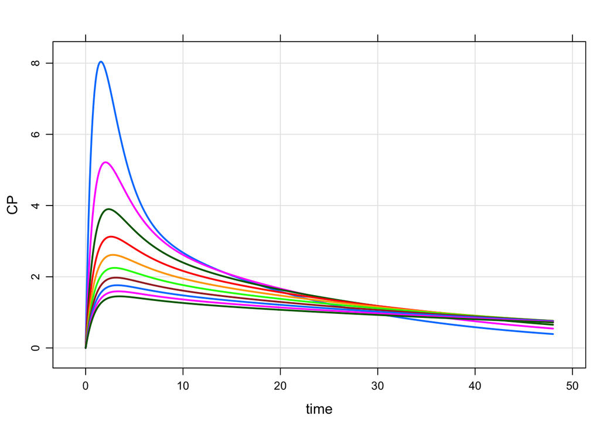

```r
sens <-
  mod %>%
  ev(amt = 100) %>%
  idata_set(idata) %>%
  mrgsim(end = 48, delta = 0.1)

plot(sens, CP~time)
```

# 3 Local sensitivity analysis

## 3.1 Sensitivity function

- Arguments
  1. `p`: parameters
  2. `e`; intervention (event) object
- Return: a data frame

```r
func <- function(p, mod, e) {
  mod %>%
    param(p) %>%
    ev(e) %>%
    mrgsim(obsonly = TRUE, atol = 1E-20) %>%
    select(-ID)
}
```

# 4 Two-comparment PK

Load this from the model library

```r
mod <- mread_cache("pk2", modlib(), delta  = 0.2, end = 72)
```

Just a simple intervention

```r
e <- ev(amt = 100)
```

## 4.1 Test the function

```r
l <- as.list(param(mod))

func(l, mod, ev(amt = 100))
```

```
## # A tibble: 361 x 5
##     time    EV  CENT PERIPH    CP
##    <dbl> <dbl> <dbl>  <dbl> <dbl>
##  1   0     0     0    0     0
##  2   0.2  81.9  17.9  0.183 0.893
##  3   0.4  67.0  32.0  0.670 1.60
##  4   0.6  54.9  43.0  1.38  2.15
##  5   0.8  44.9  51.6  2.26  2.58
##  6   1    36.8  58.2  3.25  2.91
##  7   1.2  30.1  63.2  4.32  3.16
##  8   1.4  24.7  66.9  5.43  3.35
##  9   1.6  20.2  69.6  6.55  3.48
## 10   1.8  16.5  71.4  7.68  3.57
## # … with 351 more rows
```

## 4.2 Pick some parameters for sensitivity analysis

```r
parm <- as.list(param(mod))[c("CL", "V2", "Q", "V3","KA")]
```

```r
out <- FME::sensFun(func, parm, e  = e, mod = mod)
```

Here’s the PK profile

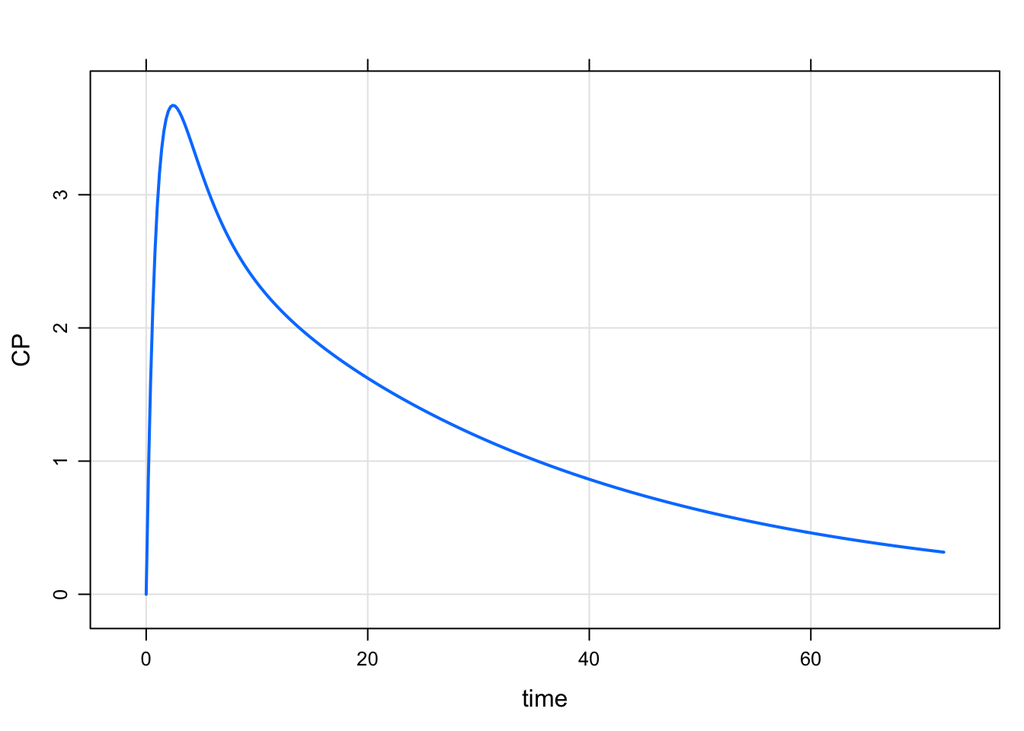

```r
mrgsim_e(mod, e, Req = "CP") %>% plot()
```

Here’s the sensitivity analysis for plasma concentration

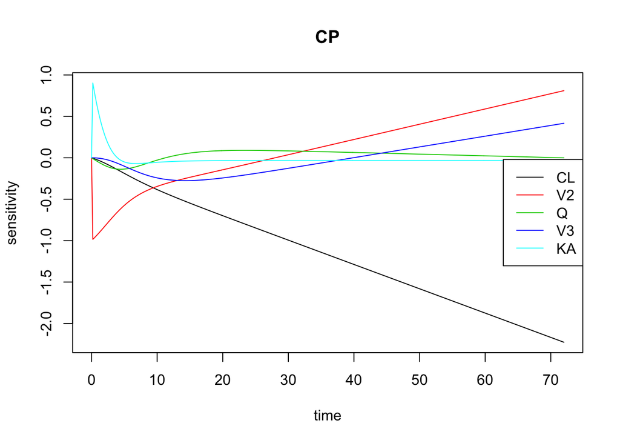

```r
plot(out, which = "CP", legpos = "right")
```

The sensitivity analysis helps us get a handle on what parameter to target for a specific feature in the profile. So if we’re interested in Cmax, we’d look at `KA` or `V2`.

Sensitivity analysis, amount in peripheral compartment

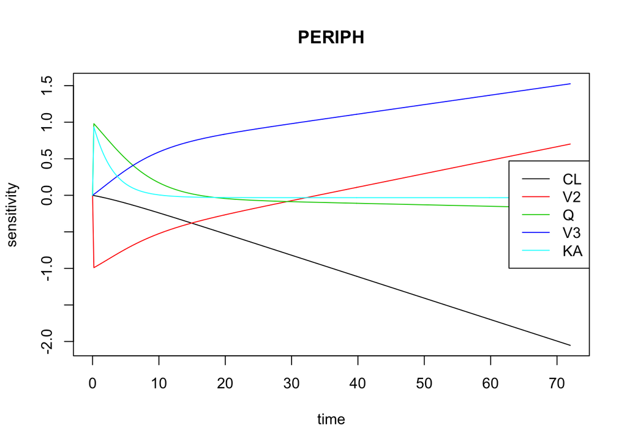

```r
plot(out, which = "PERIPH", legpos = "right")
```

```r
summary(out)
```

```
##    value scale   L1     L2   Mean    Min  Max    N
## CL     1     1 0.83 0.0290 -0.829  -2.23 0.00 1444
## V2    20    20 0.46 0.0178  0.313  -0.99 1.81 1444
## Q      2     2 0.07 0.0034  0.013  -0.17 0.98 1444
## V3    10    10 0.34 0.0146  0.255  -0.28 1.53 1444
## KA     1     1 9.04 0.5473 -9.006 -72.00 0.94 1444
```

# 5 Rifampin single dose

```r
mod <- mread_cache("rifampicin_midazolam", "model")
```

```r
e <- ev(amt = 600)
```

```r
pars <- as.list(param(mod))
```

```r
parm <- pars[c("fBCLint_all_kg", "SFKp", "ka")]
```

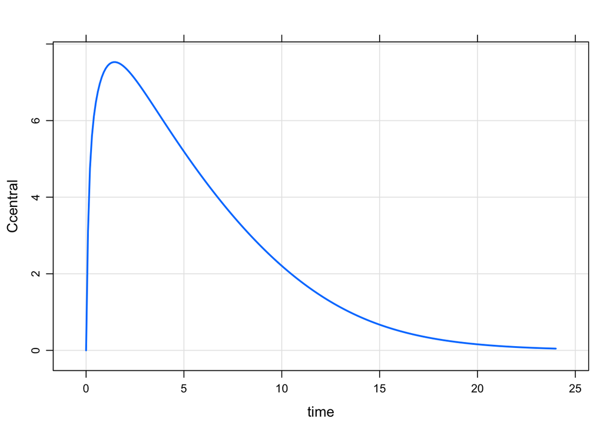

```r
mod %>%
  ev(e) %>%
  mrgsim(delta = 0.1) %>%
  plot(Ccentral ~ time)
```

```r
mod <- update(mod, end = 12, delta = 0.1)
```

```r
out <- sensFun(func, parm, e = e, mod = mod, tiny = 1E-6)
```

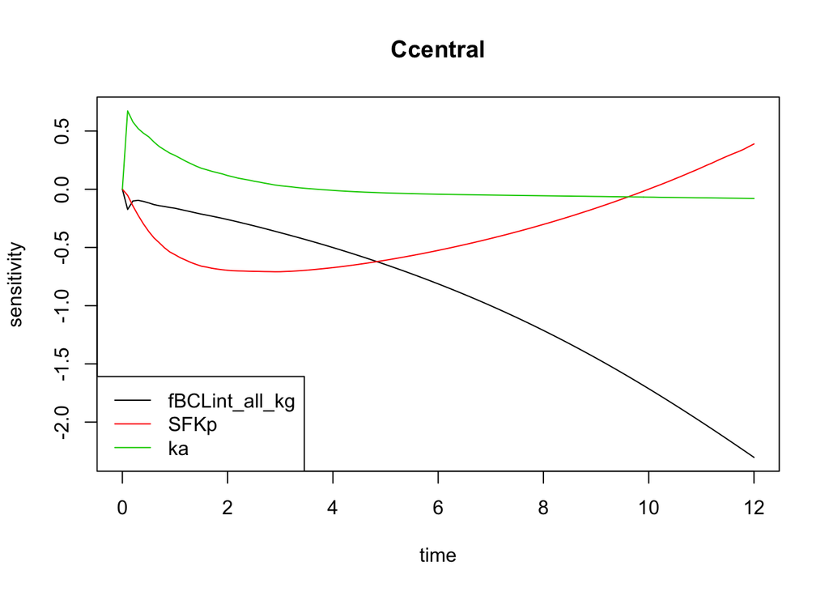

```r
plot(out, which = "Ccentral", legpos = "bottomleft")
```

# 6 Rifampin auto-induction

## 6.1 Recall the induction of rifampin metabolism via UGT

Event object for rifampin 600 mg po daily x7

```r
e <- ev(amt = 600, ii = 24, addl = 6)

mod <- update(mod, end = 168)
```

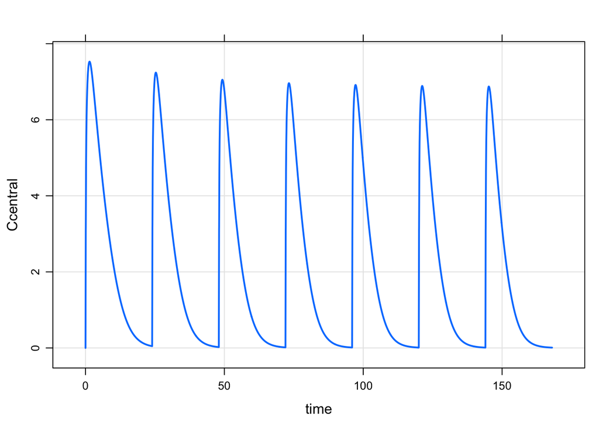

```r
mod %>%
  ev(e) %>%
  mrgsim(delta = 0.1, Req  = "Ccentral") %>%
  plot()
```

Lets look at some parameters that might be involved in this process

```r
p <- c("fBCLint_all_kg","EC50_u_UGT_RIF", "Emax_UGT_RIF")

parm <- pars[p]
```

```r
out <- sensFun(func, parm, e = e, mod = mod, tiny = 1E-6, sensvar="Ccentral")
```

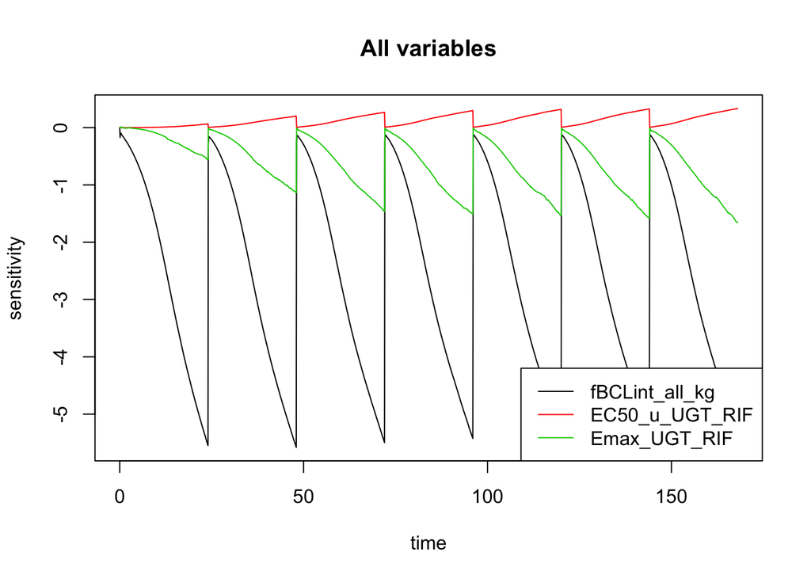

```r
plot(out, legpos = "bottomright")
```

Clearly, the rifampin concentration is very sensitive to the intrinsic clearance, especially at the trough.

Also notice that the max sensitivity grows over time for `EC50_u_UGT_RIF` and `Emax_UGT_RIF`

We want to understand what parameters are responsible for the autoinduction process: what is contributing to the reduction in AUC over the first 7 to 10 days of dosing?

Using the sensitivity analysis output, get the daily max:

```r
sum <-
  out %>%
  mutate(DAY = 1+floor(x/24)) %>%
  gather(variable,value, fBCLint_all_kg:Emax_UGT_RIF) %>%
  group_by(DAY,variable) %>%
  summarise(mx = max(abs(value)))
```

Then normalize each to day 1

```r
summ <-
  sum %>%
  group_by(variable) %>%
  mutate(normal_max = mx/first(mx))
```

Then plot over time

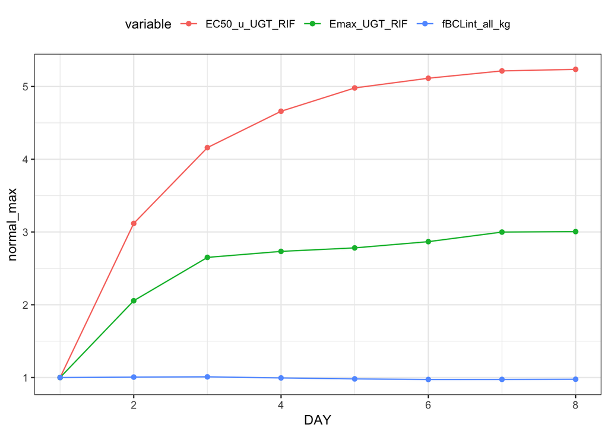

```r
ggplot(data = summ, aes(x = DAY, y = normal_max, col = variable)) +
  geom_line() + geom_point() +
  theme(legend.position = "top")
```